# Part I - (Dataset Exploration Title)

# COPYING DATAFRAME

```python
# making a copy the dataset for wrangling
loan_data = loan_df.copy()
```

# INSPECTING DATAFRAME COPY

```python
# # confirming the columns in the copy
loan_data.info()
```

```
<class 'pandas.core.frame.DataFrame'>
RangeIndex: 113937 entries, 0 to 113936
Data columns (total 81 columns):
 #   Column                               Non-Null Count   Dtype
---  ------                               --------------   -----
 0   ListingKey                           113937 non-null  object
 1   ListingNumber                        113937 non-null  int64
 2   ListingCreationDate                  113937 non-null  object
 3   CreditGrade                          28953 non-null   object
 4   Term                                 113937 non-null  int64
 5   LoanStatus                           113937 non-null  object
 6   ClosedDate                           55089 non-null   object
 7   BorrowerAPR                          113912 non-null  float64
 8   BorrowerRate                         113937 non-null  float64
 9   LenderYield                          113937 non-null  float64
```

[output cut: 73 more lines]

```python
# confirming the rows in the copy
loan_data.head(3)
```

|  | ListingKey | ListingNumber | ListingCreationDate | CreditGrade | Term | LoanStatus | ClosedDate | BorrowerAPR | BorrowerRate | LenderYield | ... | LP_ServiceFees | LP_CollectionFees | LP_GrossPrincipalLoss | LP_NetPrincipalLoss | LP_NonPrincipalRecoverypayments | PercentFunded | Recommendations | InvestmentFromFriendsCount | InvestmentFromFriendsAmount | Investors |
| --- | --- | --- | --- | --- | --- | --- | --- | --- | --- | --- | --- | --- | --- | --- | --- | --- | --- | --- | --- | --- | --- |
| 0 | 1021339766868145413AB3B | 193129 | 2007-08-26 19:09:29.263000000 | C | 36 | Completed | 2009-08-14 00:00:00 | 0.16516 | 0.158 | 0.138 | ... | -133.18 | 0.0 | 0.0 | 0.0 | 0.0 | 1.0 | 0 | 0 | 0.0 | 258 |
| 1 | 10273602499503308B223C1 | 1209647 | 2014-02-27 08:28:07.900000000 | NaN | 36 | Current | NaN | 0.12016 | 0.092 | 0.082 | ... | 0.00 | 0.0 | 0.0 | 0.0 | 0.0 | 1.0 | 0 | 0 | 0.0 | 1 |
| 2 | 0EE9337825851032864889A | 81716 | 2007-01-05 15:00:47.090000000 | HR | 36 | Completed | 2009-12-17 00:00:00 | 0.28269 | 0.275 | 0.240 | ... | -24.20 | 0.0 | 0.0 | 0.0 | 0.0 | 1.0 | 0 | 0 | 0.0 | 41 |

3 rows × 81 columns

#### EXTRACTING AND INSPECTING COLUMNS OF INTEREST

```python
# selecting columns of interest from among the dataset copy
# And re-assigning those columns to the dataframe copy afresh
loan_data = loan_data[['CreditGrade','Term','ProsperRating (numeric)','ProsperRating (Alpha)',
                      'ProsperScore','LoanStatus','BorrowerRate','IncomeRange','IncomeVerifiable',
                      'BorrowerState','Occupation','EmploymentStatus','EmploymentStatusDuration',
                      'IsBorrowerHomeowner','OnTimeProsperPayments','ProsperPrincipalBorrowed']]
```

```python
# inspecting selected columns
loan_data.info()
```

```
<class 'pandas.core.frame.DataFrame'>
RangeIndex: 113937 entries, 0 to 113936
Data columns (total 16 columns):
 #   Column                    Non-Null Count   Dtype
---  ------                    --------------   -----
 0   CreditGrade               28953 non-null   object
 1   Term                      113937 non-null  int64
 2   ProsperRating (numeric)   84853 non-null   float64
 3   ProsperRating (Alpha)     84853 non-null   object
 4   ProsperScore              84853 non-null   float64
 5   LoanStatus                113937 non-null  object
 6   BorrowerRate              113937 non-null  float64
 7   IncomeRange               113937 non-null  object
 8   IncomeVerifiable          113937 non-null  bool
 9   BorrowerState             108422 non-null  object
 10  Occupation                110349 non-null  object
 11  EmploymentStatus          111682 non-null  object
 12  EmploymentStatusDuration  106312 non-null  float64
 13  IsBorrowerHomeowner       113937 non-null  bool
 14  OnTimeProsperPayments     22085 non-null   float64
 15  ProsperPrincipalBorrowed  22085 non-null   float64
dtypes: bool(2), float64(6), int64(1), object(7)
memory usage: 12.4+ MB
```

```python
loan_data.head(10)
```

|  | CreditGrade | Term | ProsperRating (numeric) | ProsperRating (Alpha) | ProsperScore | LoanStatus | BorrowerRate | IncomeRange | IncomeVerifiable | BorrowerState | Occupation | EmploymentStatus | EmploymentStatusDuration | IsBorrowerHomeowner | OnTimeProsperPayments | ProsperPrincipalBorrowed |
| --- | --- | --- | --- | --- | --- | --- | --- | --- | --- | --- | --- | --- | --- | --- | --- | --- |
| 0 | C | 36 | NaN | NaN | NaN | Completed | 0.1580 | $25,000-49,999 | True | CO | Other | Self-employed | 2.0 | True | NaN | NaN |
| 1 | NaN | 36 | 6.0 | A | 7.0 | Current | 0.0920 | $50,000-74,999 | True | CO | Professional | Employed | 44.0 | False | NaN | NaN |
| 2 | HR | 36 | NaN | NaN | NaN | Completed | 0.2750 | Not displayed | True | GA | Other | Not available | NaN | False | NaN | NaN |
| 3 | NaN | 36 | 6.0 | A | 9.0 | Current | 0.0974 | $25,000-49,999 | True | GA | Skilled Labor | Employed | 113.0 | True | NaN | NaN |
| 4 | NaN | 36 | 3.0 | D | 4.0 | Current | 0.2085 | $100,000+ | True | MN | Executive | Employed | 44.0 | True | 11.0 | 11000.0 |
| 5 | NaN | 60 | 5.0 | B | 10.0 | Current | 0.1314 | $100,000+ | True | NM | Professional | Employed | 82.0 | True | NaN | NaN |
| 6 | NaN | 36 | 2.0 | E | 2.0 | Current | 0.2712 | $25,000-49,999 | True | KS | Sales - Retail | Employed | 172.0 | False | NaN | NaN |
| 7 | NaN | 36 | 4.0 | C | 4.0 | Current | 0.2019 | $25,000-49,999 | True | CA | Laborer | Employed | 103.0 | False | NaN | NaN |
| 8 | NaN | 36 | 7.0 | AA | 9.0 | Current | 0.0629 | $25,000-49,999 | True | IL | Food Service | Employed | 269.0 | True | NaN | NaN |
| 9 | NaN | 36 | 7.0 | AA | 11.0 | Current | 0.0629 | $25,000-49,999 | True | IL | Food Service | Employed | 269.0 | True | NaN | NaN |

```python
loan_data.describe()
```

|  | Term | ProsperRating (numeric) | ProsperScore | BorrowerRate | EmploymentStatusDuration | OnTimeProsperPayments | ProsperPrincipalBorrowed |
| --- | --- | --- | --- | --- | --- | --- | --- |
| count | 113937.000000 | 84853.000000 | 84853.000000 | 113937.000000 | 106312.000000 | 22085.000000 | 22085.000000 |
| mean | 40.830248 | 4.072243 | 5.950067 | 0.192764 | 96.071582 | 22.271949 | 8472.311961 |
| std | 10.436212 | 1.673227 | 2.376501 | 0.074818 | 94.480605 | 18.830425 | 7395.507650 |
| min | 12.000000 | 1.000000 | 1.000000 | 0.000000 | 0.000000 | 0.000000 | 0.000000 |
| 25% | 36.000000 | 3.000000 | 4.000000 | 0.134000 | 26.000000 | 9.000000 | 3500.000000 |
| 50% | 36.000000 | 4.000000 | 6.000000 | 0.184000 | 67.000000 | 15.000000 | 6000.000000 |
| 75% | 36.000000 | 5.000000 | 8.000000 | 0.250000 | 137.000000 | 32.000000 | 11000.000000 |
| max | 60.000000 | 7.000000 | 11.000000 | 0.497500 | 755.000000 | 141.000000 | 72499.000000 |

#### COLUMNS SPECIFIC INSPECTION WITH REMARKS (OR WRANGLING TIPS)

> **CreditGrade**

```python
loan_data.CreditGrade.count()
```

```
28953
```

```python
loan_data.CreditGrade.nunique()
```

```
8
```

```python
loan_data.CreditGrade.value_counts()
```

```
C     5649
D     5153
B     4389
AA    3509
HR    3508
A     3315
E     3289
NC     141
Name: CreditGrade, dtype: int64
```

> **CreditGrade Remarks**
> - Too many missing data
> - Datatype should be Categorical
> - Unclear ordering
> - Drop Column

> **Term**

```python
loan_data.Term.count()
```

```
113937
```

```python
loan_data.Term.nunique()
```

```
3
```

```python
loan_data.Term.value_counts()
```

```
36    87778
60    24545
12     1614
Name: Term, dtype: int64
```

> **Term Remarks**
> - No missing values
> - Datatype should be Ordered Categorical

> **ProsperRating (numeric)**

```python
'''loan_data.ProsperRating (numeric).count()
loan_data.ProsperRating (numeric).nunique()
loan_data.ProsperRating (numeric).value_counts()'''
```

```
'loan_data.ProsperRating (numeric).count()\nloan_data.ProsperRating (numeric).nunique()\nloan_data.ProsperRating (numeric).value_counts()'
```

> **ProsperRating (numeric) Remarks**
> - Returns error
> - Column should be renamed
> - From Visual inspection, no clear distinction on the role of the ratings
> - Column can be dropped

> **ProsperRating (Alpha)**

```python
'''loan_data.ProsperRating (Alpha).count()
loan_data.ProsperRating (Alpha).nunique()
loan_data.ProsperRating (Alpha).value_counts()'''
```

```
'loan_data.ProsperRating (Alpha).count()\nloan_data.ProsperRating (Alpha).nunique()\nloan_data.ProsperRating (Alpha).value_counts()'
```

> **ProsperRating (Alpha) Remarks**
> - Returns error
> - Column should be renamed
> - From Visual inspection, no clear distinction on the role of the ratings
> - Drop Column

> **ProsperScore**

```python
loan_data.ProsperScore.count()
```

```
84853
```

```python
loan_data.ProsperScore.nunique()
```

```
11
```

```python
loan_data.ProsperScore.value_counts()
```

```
4.0     12595
6.0     12278
8.0     12053
7.0     10597
5.0      9813
3.0      7642
9.0      6911
2.0      5766
10.0     4750
11.0     1456
1.0       992
Name: ProsperScore, dtype: int64
```

> **ProsperScore Remarks**
> - Datatype should be categorical
> - Large number of missing values
> - Drop Column

> **LoanStatus**

```python
loan_data.LoanStatus.count()
```

```
113937
```

```python
loan_data.LoanStatus.nunique()
```

```
12
```

```python
loan_data.LoanStatus.value_counts()
```

```
Current                   56576
Completed                 38074
Chargedoff                11992
Defaulted                  5018
Past Due (1-15 days)        806
Past Due (31-60 days)       363
Past Due (61-90 days)       313
Past Due (91-120 days)      304
Past Due (16-30 days)       265
FinalPaymentInProgress      205
Past Due (>120 days)         16
Cancelled                     5
Name: LoanStatus, dtype: int64
```

> **LoanStatus Remarks**
> - No missing values
> - Datatype should be object/categorical (preferably ordered categorical)

> **BorrowerRate**

```python
loan_data.BorrowerRate.count()
```

```
113937
```

```python
loan_data.BorrowerRate.nunique()
```

```
2294
```

```python
loan_data.BorrowerRate.value_counts()
```

```
0.3177    3672
0.3500    1905
0.3199    1651
0.2900    1508
0.2699    1319
          ...
0.2201       1
0.0752       1
0.1416       1
0.2812       1
0.0739       1
Name: BorrowerRate, Length: 2294, dtype: int64
```

> **BorrowerRate Remarks**
> - Datatype should be float
> - No missing values

> **IncomeRange**

```python
loan_data.IncomeRange.count()
```

```
113937
```

```python
loan_data.IncomeRange.nunique()
```

```
8
```

```python
loan_data.IncomeRange.value_counts()
```

```
$25,000-49,999    32192
$50,000-74,999    31050
$100,000+         17337
$75,000-99,999    16916
Not displayed      7741
$1-24,999          7274
Not employed        806
$0                  621
Name: IncomeRange, dtype: int64
```

> **IncomeRange Remarks**
> - Datatype should be ordered categorical
> - No missing data

> **IncomeVerifiable**

```python
loan_data.IncomeVerifiable.count()
```

```
113937
```

```python
loan_data.IncomeVerifiable.nunique()
```

```
2
```

```python
loan_data.IncomeVerifiable.value_counts()
```

```
True     105268
False      8669
Name: IncomeVerifiable, dtype: int64
```

> **IncomeVerifiable Remarks**
> - Datatype should be boolean/categorical (preferably boolean)
> - No missing data

> **BorrowerState**

```python
loan_data.BorrowerState.count()
```

```
108422
```

```python
loan_data.BorrowerState.nunique()
```

```
51
```

```python
loan_data.BorrowerState.value_counts()
```

```
CA    14717
TX     6842
NY     6729
FL     6720
IL     5921
GA     5008
OH     4197
MI     3593
VA     3278
NJ     3097
NC     3084
WA     3048
PA     2972
MD     2821
MO     2615
MN     2318
MA     2242
CO     2210
IN     2078
AZ     1901
WI     1842
OR     1817
TN     1737
AL     1679
CT     1627
SC     1122
NV     1090
KS     1062
KY      983
OK      971
LA      954
UT      877
AR      855
MS      787
NE      674
ID      599
NH      551
NM      472
RI      435
HI      409
WV      391
DC      382
MT      330
DE      300
VT      207
AK      200
SD      189
IA      186
WY      150
ME      101
ND       52
Name: BorrowerState, dtype: int64
```

> **BorrowerState Remarks**
> - Datatype should be object
> - Small amount of missing data
> - State should be written in full instead of their Postal abbreviations

> **Occupation**

```python
loan_data.Occupation.count()
```

```
110349
```

```python
loan_data.Occupation.nunique()
```

```
67
```

```python
loan_data.Occupation.value_counts()
```

```
Other                          28617
Professional                   13628
Computer Programmer             4478
Executive                       4311
Teacher                         3759
                               ...
Dentist                           68
Student - College Freshman        41
Student - Community College       28
Judge                             22
Student - Technical School        16
Name: Occupation, Length: 67, dtype: int64
```

> **Occupation Remarks**
> - Datatype should be object
> - Small amount of missing data

> **EmploymentStatus**

```python
loan_data.EmploymentStatus.count()
```

```
111682
```

```python
loan_data.EmploymentStatus.nunique()
```

```
8
```

```python
loan_data.EmploymentStatus.value_counts()
```

```
Employed         67322
Full-time        26355
Self-employed     6134
Not available     5347
Other             3806
Part-time         1088
Not employed       835
Retired            795
Name: EmploymentStatus, dtype: int64
```

> **EmploymentStatus Remarks**
> - Small amount of missing data
> - Datatype should be ordered categorical

> **EmploymentStatusDuration**

```python
loan_data.EmploymentStatusDuration.count()
```

```
106312
```

```python
loan_data.EmploymentStatusDuration.nunique()
```

```
605
```

```python
loan_data.EmploymentStatusDuration.value_counts()
```

```
0.0      1534
4.0      1186
1.0      1177
3.0      1174
2.0      1153
         ...
648.0       1
662.0       1
733.0       1
690.0       1
578.0       1
Name: EmploymentStatusDuration, Length: 605, dtype: int64
```

> **EmploymentStatusDuration Remarks**
> - Small amount of missing data
> - Datatype should be int

> **IsBorrowerHomeowner**

```python
loan_data.IsBorrowerHomeowner.count()
```

```
113937
```

```python
loan_data.IsBorrowerHomeowner.nunique()
```

```
2
```

```python
loan_data.IsBorrowerHomeowner.value_counts()
```

```
True     57478
False    56459
Name: IsBorrowerHomeowner, dtype: int64
```

> **IsBorrowerHomeowner Remarks**
> - Datatype should be boolean
> - No missing data

> **OnTimeProsperPayments**

```python
loan_data.OnTimeProsperPayments.count()
```

```
22085
```

```python
loan_data.OnTimeProsperPayments.nunique()
```

```
127
```

```python
loan_data.OnTimeProsperPayments.value_counts()
```

```
9.0      1575
6.0      1234
10.0     1146
11.0     1039
35.0      832
         ...
133.0       1
121.0       1
115.0       1
119.0       1
141.0       1
Name: OnTimeProsperPayments, Length: 127, dtype: int64
```

> **OnTimeProsperPayments Remarks**
> - Datatype should be float
> - Large number of missing values
> - Drop Column

> **ProsperPrincipalBorrowed**

```python
loan_data.ProsperPrincipalBorrowed.count()
```

```
22085
```

```python
loan_data.ProsperPrincipalBorrowed.nunique()
```

```
1442
```

```python
loan_data.ProsperPrincipalBorrowed.value_counts()
```

```
4000.0     1857
5000.0     1512
3000.0     1201
2000.0     1180
10000.0     987
           ...
15901.0       1
30600.0       1
26637.0       1
2785.0        1
33501.0       1
Name: ProsperPrincipalBorrowed, Length: 1442, dtype: int64
```

# ACT SUMMARY

- Drop CreditGrade column
- Change Term to categorical datatype
- Drop ProsperRating (numeric) column
- Drop ProsperRating (Alpha) column
- Drop ProsperScore column
- Change LoanStatus to ordered categorical datatype
- Change BorrowerRate to float datatype
- Change IncomeRange to ordered categorical datatype
- Change IncomeVerifiable to boolean datatype
- Change BorrowerState to object datatype
- Change Occupation to object datatype
- Change EmploymentStatus to ordered categorical datatype
- Change EmploymentStatusDuration to int datatype
- Change IsBorrowerHomeowner to boolean datatype
- Drop OnTimeProsperPayments column
- Drop ProsperPrincipalBorrowed column
- Drop all NaN or null entries in the dataframe (much later)

# WRANGLING PHASE

##### dropping columns

```python
# dropping columns
loan_data.drop(['CreditGrade','ProsperRating (numeric)','ProsperRating (Alpha)',
              'ProsperScore','OnTimeProsperPayments','ProsperPrincipalBorrowed'], axis=1, inplace=True)
loan_data.info()
```

```
<class 'pandas.core.frame.DataFrame'>
RangeIndex: 113937 entries, 0 to 113936
Data columns (total 10 columns):
 #   Column                    Non-Null Count   Dtype
---  ------                    --------------   -----
 0   Term                      113937 non-null  int64
 1   LoanStatus                113937 non-null  object
 2   BorrowerRate              113937 non-null  float64
 3   IncomeRange               113937 non-null  object
 4   IncomeVerifiable          113937 non-null  bool
 5   BorrowerState             108422 non-null  object
 6   Occupation                110349 non-null  object
 7   EmploymentStatus          111682 non-null  object
 8   EmploymentStatusDuration  106312 non-null  float64
 9   IsBorrowerHomeowner       113937 non-null  bool
dtypes: bool(2), float64(2), int64(1), object(5)
memory usage: 7.2+ MB
```

```python
# Quick description
loan_data.describe()
```

|  | Term | BorrowerRate | EmploymentStatusDuration |
| --- | --- | --- | --- |
| count | 113937.000000 | 113937.000000 | 106312.000000 |
| mean | 40.830248 | 0.192764 | 96.071582 |
| std | 10.436212 | 0.074818 | 94.480605 |
| min | 12.000000 | 0.000000 | 0.000000 |
| 25% | 36.000000 | 0.134000 | 26.000000 |
| 50% | 36.000000 | 0.184000 | 67.000000 |
| 75% | 36.000000 | 0.250000 | 137.000000 |
| max | 60.000000 | 0.497500 | 755.000000 |

##### converting to categorical dtype

```python
# importing CategoricalDtype
from pandas.api.types import CategoricalDtype
```

```python
# due to the need to specify order in our Categorical variables as our project warrants
# we create a dictionary to specify the order we want our categorical variables to follow
conversion_dict = {
    'Term': [12, 36, 60],
    'LoanStatus': ['Cancelled', 'Chargedoff', 'Completed', 'Current',
                  'Defaulted', 'FinalPaymentInProgress',
                  'Past Due (1-15 days)', 'Past Due (16-30 days)',
                  'Past Due (31-60 days)', 'Past Due (61-90 days)',
                  'Past Due (91-120 days)', 'Past Due (>120 days)'],
    'IncomeRange': ['$0', '$1-24,999', '$25,000-49,999',
                  '$50,000-74,999', '$75,000-99,999', '$100,000+', 'Not displayed',
                  'Not employed'],
    'EmploymentStatus': ['Employed', 'Full-time', 'Not available', 'Not employed',
                  'Other', 'Part-time', 'Retired', 'Self-employed']
}

# here, we set the order we have created
for category in conversion_dict:
    set_order = pd.api.types.CategoricalDtype(categories=conversion_dict[category], ordered=True)
    loan_data[category] = loan_data[category].astype(set_order)
```

```python
# checking to confirm column datatype
loan_data.info()
```

```
<class 'pandas.core.frame.DataFrame'>
RangeIndex: 113937 entries, 0 to 113936
Data columns (total 10 columns):
 #   Column                    Non-Null Count   Dtype
---  ------                    --------------   -----
 0   Term                      113937 non-null  category
 1   LoanStatus                113937 non-null  category
 2   BorrowerRate              113937 non-null  float64
 3   IncomeRange               113937 non-null  category
 4   IncomeVerifiable          113937 non-null  bool
 5   BorrowerState             108422 non-null  object
 6   Occupation                110349 non-null  object
 7   EmploymentStatus          111682 non-null  category
 8   EmploymentStatusDuration  106312 non-null  float64
 9   IsBorrowerHomeowner       113937 non-null  bool
dtypes: bool(2), category(4), float64(2), object(2)
memory usage: 4.1+ MB
```

##### Replacing BorrowerState postals with actual state names

```python
# Replacing the postals with actual state names

loan_data.replace({'BorrowerState' : {'AK':'Alaska','AL':'Alabama','AR':'Arkansas','AZ':'Arizona','CA':'California','CO':'Colorado',
'CT':'Connecticut','DC':'District of Columbia','DE':'Delaware','FL':'Florida','GA':'Georgia',
'HI':'Hawaii','IA':'Iowa','ID':'Idaho','IL':'Illinois','IN':'Indiana','KS':'Kansas','KY':'Kentucky',
'LA':'Louisiana','MA':'Massachusetts','MD':'Maryland','ME':'Maine','MI':'Michigan','MN':'Minnesota',
'MO':'Missouri','MS':'Mississippi','MT':'Montana','NC':'North Carolina','ND':'North Dakota',
'NE':'Nebraska','NH':'New Hampshire','NJ':'New Jersey','NM':'New Mexico','NV':'Nevada','NY':'New York',
'OH':'Ohio','OK':'Oklahoma','OR':'Oregon','PA':'Pennsylvania','RI':'Rhode Island','SC':'South Carolina',
'SD':'South Dakota','TN':'Tennessee','TX':'Texas','UT':'Utah','VA':'Virginia','VT':'Vermont',
'WA':'Washington','WI':'Wisconsin','WV':'West Virginia','WY':'Wyoming'}},inplace=True)
```

```python
# confirming change in BorrowerState column
loan_data.head()
```

|  | Term | LoanStatus | BorrowerRate | IncomeRange | IncomeVerifiable | BorrowerState | Occupation | EmploymentStatus | EmploymentStatusDuration | IsBorrowerHomeowner |
| --- | --- | --- | --- | --- | --- | --- | --- | --- | --- | --- |
| 0 | 36 | Completed | 0.1580 | $25,000-49,999 | True | Colorado | Other | Self-employed | 2.0 | True |
| 1 | 36 | Current | 0.0920 | $50,000-74,999 | True | Colorado | Professional | Employed | 44.0 | False |
| 2 | 36 | Completed | 0.2750 | Not displayed | True | Georgia | Other | Not available | NaN | False |
| 3 | 36 | Current | 0.0974 | $25,000-49,999 | True | Georgia | Skilled Labor | Employed | 113.0 | True |
| 4 | 36 | Current | 0.2085 | $100,000+ | True | Minnesota | Executive | Employed | 44.0 | True |

# DATA EXPLORATION PHASE

### What is the structure of your dataset?

> The dataset has 113,937 rows and 81 columns

### What is/are the main feature(s) of interest in your dataset?

> FEATURES OF INTEREST
> - What loan schemes are the most favored?
> - What is the social status of the loan applicants?
> - How does IncomeRange affects a loan application?
> - Which State did most of the borrowers come from?
> - How does Employment Status affect a loan application?
> - How does being a Homeowner affects loan application?

### What features in the dataset do you think will help support your investigation into your feature(s) of interest?

> FEATURES IN DATASET
> - CreditGrade
> - Term
> - ProsperRating (numeric)
> - ProsperRating (Alpha)
> - ProsperScore
> - LoanStatus
> - BorrowerRate
> - IncomeRange
> - IncomeVerifiable
> - BorrowerState
> - Occupation
> - EmploymentStatus
> - EmploymentStatusDuration
> - IsBorrowerHomeowner
> - OnTimeProsperPayments
> - ProsperPrincipalBorrowed

# CREATING PLOT FUNCTIONS

```python
# Function to create reg plot
def reg_plot(x, y, **kwargs):
    """ Quick hack for creating reg plots with seaborn's PairGrid. """
    ax = sns.regplot(x=x, y=y, color='b')
    ax.tick_params(rotation=90)
```

```python
# Plot_bar function to help with plotting bars using Seaborn
def bar_plot(x, y, height, labels = None, title = None,
             xlabel = None, ylabel=None, color = None):
    sns.set_style('darkgrid')
    plt.bar(x, y, height, tick_label = labels, color = color, width = 0.2)
    plt.title(title, weight = 'bold', fontsize = 15)
    plt.xlabel(xlabel, weight = 'bold', fontsize = 12)
    plt.ylabel(ylabel, weight = 'bold', fontsize = 12)
    plt.show
```

```python
def count_plot(data=None, x=None, y=None, hue=None, color=None, height=None, width=None,
               title=None, order=None, xlabel=None, ylabel=None, rotation=None, **kwargs):

    sns.set(rc={'figure.figsize':(width,height)})

    sns.countplot(data=data, x=x, y=y, hue=hue, color=color, order=order, **kwargs)
    plt.title(title, weight = 'bold', fontsize = 15)
    plt.xticks(rotation=rotation);
    plt.xlabel(xlabel, weight = 'medium', fontsize = 12)
    plt.ylabel(ylabel, weight = 'medium', fontsize = 12)
    plt.show
```

```python
def factor_plot(x, y, data=None, xlabel=None, ylabel=None,
                title=None, rotation=None, height=None, width=None, **kwargs):

    plt.figure(figsize=[height,width])

    # Function to add a main title to all subplots
    plt.suptitle(title.title(), y = 1,
            fontsize = 15, weight = "bold")

    # Function to maximize distance between subplots
    plt.tight_layout()

    # Function to create violin plot
    plt.subplot(1,2,1)
    sns.violinplot(data=data, x=x,y=y)
    plt.xticks(rotation=rotation);
    plt.xlabel(xlabel, weight = 'medium', fontsize = 12)
    plt.ylabel(ylabel, weight = 'medium', fontsize = 12)
    plt.show

    # Function to create box plot
    plt.subplot(1,2,2)
    sns.boxplot(data=data, x=x,y=y)
    plt.xticks(rotation=rotation);
    plt.xlabel(xlabel, weight = 'medium', fontsize = 12)
    plt.ylabel(ylabel, weight = 'medium', fontsize = 12)
    plt.show
```

# HANDLING NULL VALUES

#### DROPPING NULL OR NAN VALUES EVERYWHERE IN THE DATASET

```python
# copying a temporary version (with non-null values) of the active dataframe into a new dataframe
loan_non_null_df = loan_data.dropna(inplace=False)

# checking the new copy
loan_non_null_df
```

|  | Term | LoanStatus | BorrowerRate | IncomeRange | IncomeVerifiable | BorrowerState | Occupation | EmploymentStatus | EmploymentStatusDuration | IsBorrowerHomeowner |
| --- | --- | --- | --- | --- | --- | --- | --- | --- | --- | --- |
| 0 | 36 | Completed | 0.1580 | $25,000-49,999 | True | Colorado | Other | Self-employed | 2.0 | True |
| 1 | 36 | Current | 0.0920 | $50,000-74,999 | True | Colorado | Professional | Employed | 44.0 | False |
| 3 | 36 | Current | 0.0974 | $25,000-49,999 | True | Georgia | Skilled Labor | Employed | 113.0 | True |
| 4 | 36 | Current | 0.2085 | $100,000+ | True | Minnesota | Executive | Employed | 44.0 | True |
| 5 | 60 | Current | 0.1314 | $100,000+ | True | New Mexico | Professional | Employed | 82.0 | True |
| ... | ... | ... | ... | ... | ... | ... | ... | ... | ... | ... |
| 113932 | 36 | Current | 0.1864 | $50,000-74,999 | True | Illinois | Food Service Management | Employed | 246.0 | True |
| 113933 | 36 | FinalPaymentInProgress | 0.1110 | $75,000-99,999 | True | Pennsylvania | Professional | Employed | 21.0 | True |
| 113934 | 60 | Current | 0.2150 | $25,000-49,999 | True | Texas | Other | Employed | 84.0 | True |
| 113935 | 60 | Completed | 0.2605 | $25,000-49,999 | True | Georgia | Food Service | Full-time | 94.0 | True |
| 113936 | 36 | Current | 0.1039 | $50,000-74,999 | True | New York | Professor | Employed | 244.0 | False |

103245 rows × 10 columns

```python
# confirming that all columns have same amount of non-null values
loan_non_null_df.info()
```

```
<class 'pandas.core.frame.DataFrame'>
Int64Index: 103245 entries, 0 to 113936
Data columns (total 10 columns):
 #   Column                    Non-Null Count   Dtype
---  ------                    --------------   -----
 0   Term                      103245 non-null  category
 1   LoanStatus                103245 non-null  category
 2   BorrowerRate              103245 non-null  float64
 3   IncomeRange               103245 non-null  category
 4   IncomeVerifiable          103245 non-null  bool
 5   BorrowerState             103245 non-null  object
 6   Occupation                103245 non-null  object
 7   EmploymentStatus          103245 non-null  category
 8   EmploymentStatusDuration  103245 non-null  float64
 9   IsBorrowerHomeowner       103245 non-null  bool
dtypes: bool(2), category(4), float64(2), object(2)
memory usage: 4.5+ MB
```

**COMPARING BOTH DATAFRAMES**

```python
# checking the structure of the active dataframe
loan_data.shape
```

```
(113937, 10)
```

```python
# checking the structure of the non-null dataframe
loan_non_null_df.shape
```

```
(103245, 10)
```

```python
# description of the columns in the active dataframe
loan_data.describe()
```

|  | BorrowerRate | EmploymentStatusDuration |
| --- | --- | --- |
| count | 113937.000000 | 106312.000000 |
| mean | 0.192764 | 96.071582 |
| std | 0.074818 | 94.480605 |
| min | 0.000000 | 0.000000 |
| 25% | 0.134000 | 26.000000 |
| 50% | 0.184000 | 67.000000 |
| 75% | 0.250000 | 137.000000 |
| max | 0.497500 | 755.000000 |

```python
# description of the columns in the non-null dataframe
loan_non_null_df.describe()
```

|  | BorrowerRate | EmploymentStatusDuration |
| --- | --- | --- |
| count | 103245.000000 | 103245.000000 |
| mean | 0.193415 | 96.937043 |
| std | 0.075538 | 93.937354 |
| min | 0.000000 | 0.000000 |
| 25% | 0.133500 | 27.000000 |
| 50% | 0.184000 | 68.000000 |
| 75% | 0.253700 | 138.000000 |
| max | 0.360000 | 755.000000 |

#### PERCENTAGE (%) OF ORIGINAL DATA RETAINED

```python
Retainance_Perc = (float(loan_non_null_df.shape[0]/loan_data.shape[0])*100)
Retainance_Perc
```

```
90.61586666315596
```

##### Note:

> It wouldn't be a bad idea to drop all NaN entries/null values as there is still a large percentage of the dataset retained however, due to the uneven distribution of null values, I wouldn't do this straightaway.

> The NaN/null values per column when inspected visually doesn't happen to fall in the same row across all the columns, meaning someone could be missing an IncomeRange entry but have their BorrowerState entry filled. Therefore dropping the null values across the dataframe so quickly would eliminate the chance of counting such person's BorrowerState during a CountPlot

**That said, the Exploratory Data Analysis from here on shall be done as follows:**

> **(1) For univariate plots and QVOs (Question-Visualization-Observation) requiring just one column to answer, we would drop the NaNs per column while attempting to answer and plot them.**

> **(2) For those QVOs requiring a combination of two columns or more, we would use the cleaner non-null dataframe like the loan_non_null_df (with over 90% Data Retainance Percentage) to answer and plot them.**

# Question-Visualization-Observation

# UNIVARIATE EXPLORATORY ANALYSIS

```
> Which is the commonest loan term?
```

```python
loan_data.Term.dtype
```

```
CategoricalDtype(categories=[12, 36, 60], ordered=True)
```

```python
loan_data.Term.value_counts()
```

```
36    87778
60    24545
12     1614
Name: Term, dtype: int64
```

#### Visualization(s)

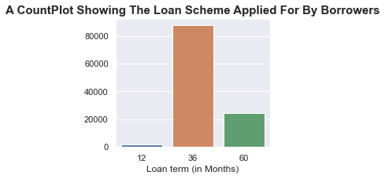

```python
count_plot(data = loan_data, x = 'Term',  xlabel="Loan term (in Months)", height=3, width=3.5,
           title='A CountPlot Showing The Loan Scheme Applied For By Borrowers', rotation=0);
```

#### Observation:

**Commonest loan period is 36 months**

```
> How is the BorrowerRate distributed?
```

```python
loan_data.BorrowerRate.value_counts()
```

```
0.3177    3672
0.3500    1905
0.3199    1651
0.2900    1508
0.2699    1319
          ...
0.2201       1
0.0752       1
0.1416       1
0.2812       1
0.0739       1
Name: BorrowerRate, Length: 2294, dtype: int64
```

```python
loan_data.BorrowerRate.describe()
```

```
count    113937.000000
mean          0.192764
std           0.074818
min           0.000000
25%           0.134000
50%           0.184000
75%           0.250000
max           0.497500
Name: BorrowerRate, dtype: float64
```

```python
loan_data.BorrowerRate.nunique()
```

```
2294
```

#### Visualization(s)

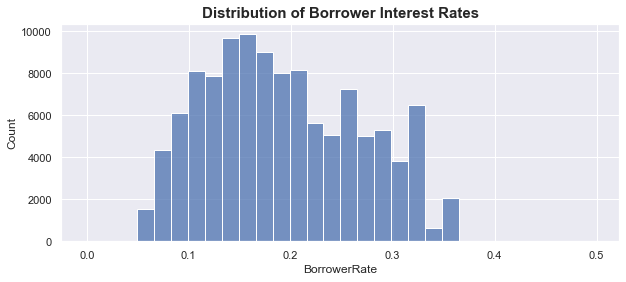

```python
# setting parameters for visualization
sns.set(rc={'figure.figsize':(10,4)})

# histplot of Borrower Rates
sns.histplot(data=loan_data, x="BorrowerRate", bins=30);
plt.title('Distribution of Borrower Interest Rates', fontsize=15, weight="bold")
```

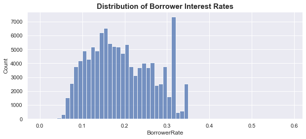

```python
# setting parameters for visualization
sns.set(rc={'figure.figsize':(10,4)})

# adjusting bin sizes
bins = np.arange(0, loan_data.BorrowerRate.max()+0.1, 0.01)

sns.histplot(data=loan_data, x="BorrowerRate", bins=bins);
plt.title('Distribution of Borrower Interest Rates', fontsize=15, weight="bold");
```

#### Observation:

**Initially, it would appear as if the highest rate is between 0.1 and 0.2 (the range where most values fall), however, adjusting the bin sizes coud offer new insights**

**After adjusting the bins and re-plotting the histogram, most values still seem to distribute around the left and between .1 and .2 however, the peak changes when the bins are adjusted**

```
> WHat is the Income range of the applicants?
```

```python
loan_data.IncomeRange.value_counts()
```

```
$25,000-49,999    32192
$50,000-74,999    31050
$100,000+         17337
$75,000-99,999    16916
Not displayed      7741
$1-24,999          7274
Not employed        806
$0                  621
Name: IncomeRange, dtype: int64
```

#### Visualization(s)

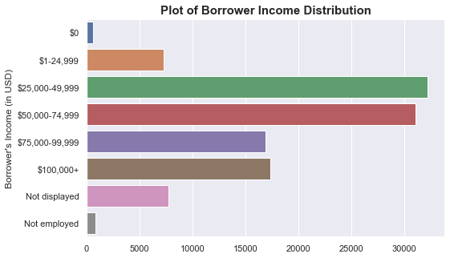

```python
count_plot(data = loan_data, y = 'IncomeRange',  ylabel="Borrower's Income (in USD)", height=5, width=8,
           title='Plot of Borrower Income Distribution', rotation=0);
```

#### Observation:

**Most applicants have their income between 25,000 - 74,999 USD**

```
> How many applicants can verify their income?
```

```python
loan_data.IncomeVerifiable.value_counts()
```

```
True     105268
False      8669
Name: IncomeVerifiable, dtype: int64
```

#### Visualization(s)

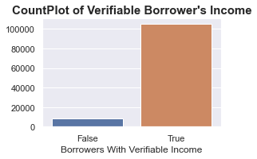

```python
count_plot(data = loan_data, x = 'IncomeVerifiable',  xlabel='Borrowers With Verifiable Income', height=2.5, width=4,
           title="CountPlot of Verifiable Borrower's Income", rotation=0);
```

#### Observation:

**Most applicants have a way of verifying their income**

```
> Occupational Distribution of the Borrowers

    - To do this, I agree it makes more sense to plot the borrower occupation alphabetically so the graph is easier to read
```

##### START OF OCCUPATION ALPHABETICAL SORTING & PLOTTING

```python
loan_data.sort_values(by=['Occupation'], inplace=False, ascending=True)
```

|  | Term | LoanStatus | BorrowerRate | IncomeRange | IncomeVerifiable | BorrowerState | Occupation | EmploymentStatus | EmploymentStatusDuration | IsBorrowerHomeowner |
| --- | --- | --- | --- | --- | --- | --- | --- | --- | --- | --- |
| 106804 | 60 | Current | 0.2694 | $75,000-99,999 | True | Nevada | Accountant/CPA | Employed | 48.0 | False |
| 56482 | 60 | Current | 0.2220 | $25,000-49,999 | False | Texas | Accountant/CPA | Self-employed | 54.0 | False |
| 4536 | 36 | Current | 0.0699 | $50,000-74,999 | True | New York | Accountant/CPA | Employed | 156.0 | False |
| 65346 | 36 | Completed | 0.2346 | $25,000-49,999 | True | California | Accountant/CPA | Employed | 42.0 | False |
| 102623 | 36 | Completed | 0.1020 | $100,000+ | True | Oregon | Accountant/CPA | Full-time | 185.0 | True |
| ... | ... | ... | ... | ... | ... | ... | ... | ... | ... | ... |
| 113709 | 36 | Current | 0.2925 | $25,000-49,999 | True | Minnesota | NaN | Other | 85.0 | False |
| 113712 | 36 | Defaulted | 0.2375 | Not displayed | True | Maryland | NaN | NaN | NaN | False |
| 113902 | 36 | Completed | 0.0812 | Not displayed | True | NaN | NaN | NaN | NaN | False |
| 113914 | 36 | Defaulted | 0.2500 | Not displayed | True | California | NaN | NaN | NaN | False |
| 113921 | 36 | Completed | 0.0400 | Not displayed | True | NaN | NaN | NaN | NaN | False |

113937 rows × 10 columns

```python
occupation_list = loan_data['Occupation'].tolist()
occupation_list
```

[output not shown]

[output cut: 946 more lines]

[output not shown]

```python
len(occupation_list)
```

```
113937
```

```python
occupation_alpha_list = [job for job in occupation_list if str(job) != 'nan']
occupation_alpha_list
```

[output not shown]

[output cut: 946 more lines]

[output not shown]

```python
len(occupation_alpha_list)
```

```
110349
```

```python
occupation_alpha_list.sort()
occupation_alpha_list

set(occupation_alpha_list)

unique_list = set(occupation_alpha_list)
new_sort = sorted(list(unique_list))
new_sort
```

```
['Accountant/CPA',
 'Administrative Assistant',
 'Analyst',
 'Architect',
 'Attorney',
 'Biologist',
 'Bus Driver',
 'Car Dealer',
 'Chemist',
 'Civil Service',
 'Clergy',
 'Clerical',
 'Computer Programmer',
 'Construction',
 'Dentist',
 'Doctor',
 'Engineer - Chemical',
 'Engineer - Electrical',
 'Engineer - Mechanical',
 'Executive',
 'Fireman',
 'Flight Attendant',
 'Food Service',
 'Food Service Management',
 'Homemaker',
 'Investor',
 'Judge',
 'Laborer',
 'Landscaping',
 'Medical Technician',
 'Military Enlisted',
 'Military Officer',
 'Nurse (LPN)',
 'Nurse (RN)',
 "Nurse's Aide",
 'Other',
 'Pharmacist',
 'Pilot - Private/Commercial',
 'Police Officer/Correction Officer',
 'Postal Service',
```

[output cut: 12 more lines]

```
 'Student - College Freshman',
 'Student - College Graduate Student',
 'Student - College Junior',
 'Student - College Senior',
 'Student - College Sophomore',
 'Student - Community College',
 'Student - Technical School',
 'Teacher',
 "Teacher's Aide",
 'Tradesman - Carpenter',
 'Tradesman - Electrician',
 'Tradesman - Mechanic',
 'Tradesman - Plumber',
 'Truck Driver',
 'Waiter/Waitress']
```

#### Visualization(s)

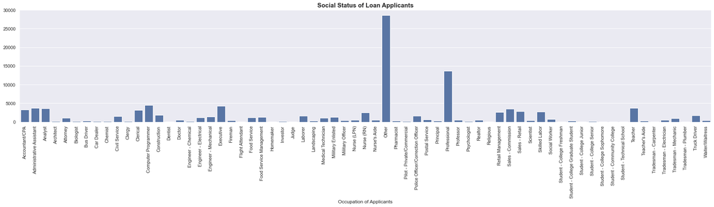

```python
count_plot(data = loan_data, x = 'Occupation',  xlabel='Occupation of Applicants', height=5, width=30,
           title='Social Status of Loan Applicants', order=new_sort, rotation=90, color = sns.color_palette()[0]);
```

##### END OF OCCUPATION ALPHABETICAL SORTING & PLOTTING

#### Observation:

**Majority of the applicants aren't neccessarily collar-job officers. Students are among those who get the least loan approvals and I'd argue it's because they likely make no income for a refund. With all the categories and their low count, I'd say the major part of the "Others" are likely to be business oriented personnels/bodies.**

```
> Which State did most of the borrowers come from?

    - To do this as well, I agree it makes more sense to plot the borrower states alphabetically so the graph is easier to read
```

##### START OF BORROWER STATE ALPHABETICAL SORTING & PLOTTING

```python
loan_data['BorrowerState'].value_counts(dropna=False)
```

```
California              14717
Texas                    6842
New York                 6729
Florida                  6720
Illinois                 5921
NaN                      5515
Georgia                  5008
Ohio                     4197
Michigan                 3593
Virginia                 3278
New Jersey               3097
North Carolina           3084
Washington               3048
Pennsylvania             2972
Maryland                 2821
Missouri                 2615
Minnesota                2318
Massachusetts            2242
Colorado                 2210
Indiana                  2078
Arizona                  1901
Wisconsin                1842
Oregon                   1817
Tennessee                1737
Alabama                  1679
Connecticut              1627
South Carolina           1122
Nevada                   1090
Kansas                   1062
Kentucky                  983
Oklahoma                  971
Louisiana                 954
Utah                      877
Arkansas                  855
Mississippi               787
Nebraska                  674
Idaho                     599
New Hampshire             551
New Mexico                472
Rhode Island              435
Hawaii                    409
West Virginia             391
District of Columbia      382
Montana                   330
Delaware                  300
Vermont                   207
Alaska                    200
South Dakota              189
Iowa                      186
Wyoming                   150
Maine                     101
North Dakota               52
Name: BorrowerState, dtype: int64
```

```python
loan_data['BorrowerState'].nunique()
```

```
51
```

```python
loan_data['BorrowerState'].isna().sum()
```

```
5515
```

```python
loan_data['BorrowerState']
```

```
0             Colorado
1             Colorado
2              Georgia
3              Georgia
4            Minnesota
              ...
113932        Illinois
113933    Pennsylvania
113934           Texas
113935         Georgia
113936        New York
Name: BorrowerState, Length: 113937, dtype: object
```

```python
full_state_name = loan_data['BorrowerState'].tolist()
len(full_state_name)
```

```
113937
```

```python
full_state_name = [name for name in full_state_name if str(name) != 'nan']
len(full_state_name)
```

```
108422
```

```python
full_state_name.sort()

set(full_state_name)

state_name_alpha = set(full_state_name)
ord_state = sorted(list(state_name_alpha))
ord_state
```

```
['Alabama',
 'Alaska',
 'Arizona',
 'Arkansas',
 'California',
 'Colorado',
 'Connecticut',
 'Delaware',
 'District of Columbia',
 'Florida',
 'Georgia',
 'Hawaii',
 'Idaho',
 'Illinois',
 'Indiana',
 'Iowa',
 'Kansas',
 'Kentucky',
 'Louisiana',
 'Maine',
 'Maryland',
 'Massachusetts',
 'Michigan',
 'Minnesota',
 'Mississippi',
 'Missouri',
 'Montana',
 'Nebraska',
 'Nevada',
 'New Hampshire',
 'New Jersey',
 'New Mexico',
 'New York',
 'North Carolina',
 'North Dakota',
 'Ohio',
 'Oklahoma',
 'Oregon',
 'Pennsylvania',
 'Rhode Island',
 'South Carolina',
 'South Dakota',
 'Tennessee',
 'Texas',
 'Utah',
 'Vermont',
 'Virginia',
 'Washington',
 'West Virginia',
 'Wisconsin',
 'Wyoming']
```

#### Visualization(s)

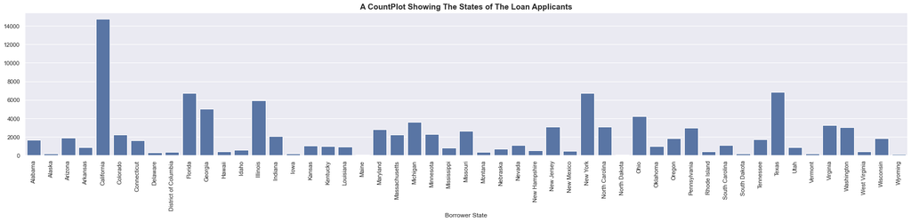

```python
count_plot(data = loan_data, x = 'BorrowerState',  xlabel='Borrower State', height=5, width=30,
           title='A CountPlot Showing The States of The Loan Applicants', order=ord_state, rotation=90, color = sns.color_palette()[0]);
```

##### END OF BORROWER STATE ALPHABETICAL SORTING & PLOTTING

#### Observation:

**Majority of the applicants are from California with about twice as many applicants as those from the next highest state**

```
> How many applicants are employed and how long have they been employed?
```

#### Visualization(s)

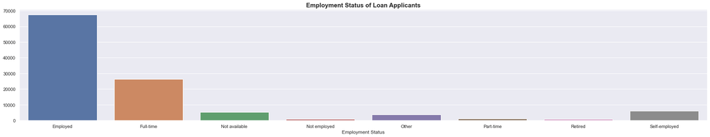

```python
count_plot(data = loan_data, x = 'EmploymentStatus',  xlabel='Employment Status', height=5, width=30,
           title='Employment Status of Loan Applicants');
```

[figure not shown]

```python
count_plot(data = loan_data, x = 'EmploymentStatusDuration',  xlabel='Employment Status Duration (in Months)', height=8, width=30,
           title=' A CountPlot Showing The Employment Status Duration of The Loan Applicants', color = sns.color_palette()[0]);
```

#### Observation:

**Most beneficiaries are employed but less than half have full time employments and even way lesser are self-employed. This could likely correspond with my assumption of business oriented personnels because, if someone works a job part time, they likely need funds for their side-hustles/other business to look after families and mortgages and all. Plus, having a means of employment is a strong criteria for obtaining loans as one would likely ssume due to the need for a refund with interest**

```
> How does being a Homeowner affects loan application?
```

#### Visualization(s)

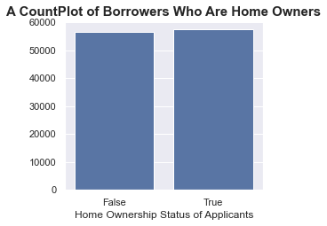

```python
count_plot(data = loan_data, x = 'IsBorrowerHomeowner',  xlabel='Home Ownership Status of Applicants', height=3.5, width=4,
           title='A CountPlot of Borrowers Who Are Home Owners', color = sns.color_palette()[0]);
```

#### Observation:

**Well there are almost as many Non Home Owners are there are Home Owners so the idea of a collateral is quickly downtrodden. I presume it wont be a strong criteria.**

# BIVARIATE & MULTIVARIATE

### Comparing Variables for Plot types:

1. Quantitative & Quantitative
   - BorrowerRate & EmploymentStatusDuration
2. Qualitative/Others & Quantitative
   - BorrowerRate & IsBorrowerHomeOwner
3. Quantitative & Categorical
   - BorrowerRate & Term
   - ~~BorrowerRate & IncomeRange ~~
   - BorrowerRate & EmploymentStatus
4. Categorical & Categorical
   - Term & LoanStatus (facetgrid by Term)
   - Term & IncomeRange
   - Term & EmploymentStatus
   - LoanStatus & IncomeRange (facetgrid by IncomeRange)
   - LoanStatus & EmploymentStatus
   - IncomeRange & EmploymentStatus(Not really important)
5. Qualitative & Qualitative/Categorical
   - BorrowerState & IncomeVerifiable
   - IsborrowerHomeOwner & IncomeVerifiable
   - IsborrowerHomeOwner & BorrowerState
   - IsborrowerHomeOwner & LoanStatus
   - IsborrowerHomeOwner & Term

# EXPLANATORY QUESTIONS

> - What loan schemes are the most favored?
> - What is the social status of the loan applicants?
> - How does IncomeRange affects a loan application?
> - Which State did most of the borrowers come from?
> - How does Employment Status affect a loan application?
> - How does being a Homeowner affects loan application?

```
   > BorrowerRate & EmploymentStatusDuration
```

```python
loan_data.info()
```

```
<class 'pandas.core.frame.DataFrame'>
RangeIndex: 113937 entries, 0 to 113936
Data columns (total 10 columns):
 #   Column                    Non-Null Count   Dtype
---  ------                    --------------   -----
 0   Term                      113937 non-null  category
 1   LoanStatus                113937 non-null  category
 2   BorrowerRate              113937 non-null  float64
 3   IncomeRange               113937 non-null  category
 4   IncomeVerifiable          113937 non-null  bool
 5   BorrowerState             108422 non-null  object
 6   Occupation                110349 non-null  object
 7   EmploymentStatus          111682 non-null  category
 8   EmploymentStatusDuration  106312 non-null  float64
 9   IsBorrowerHomeowner       113937 non-null  bool
dtypes: bool(2), category(4), float64(2), object(2)
memory usage: 4.1+ MB
```

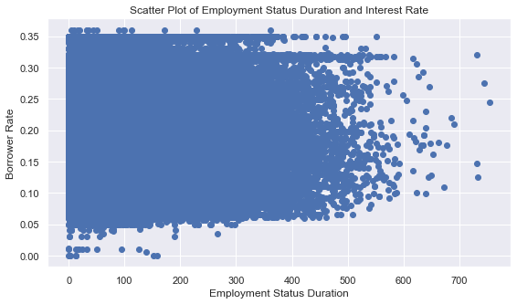

```python
plt.figure(figsize=[20,5])

plt.subplot(1,2,1)
plt.scatter(data=loan_data, x='EmploymentStatusDuration', y='BorrowerRate');
plt.xlabel('Employment Status Duration')
plt.ylabel('Borrower Rate')
plt.title('Scatter Plot of Employment Status Duration and Interest Rate');
```

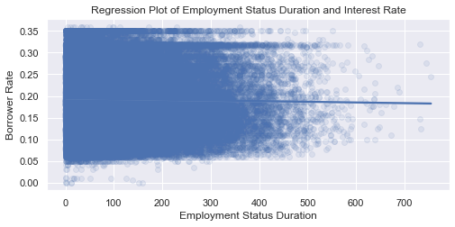

```python
sns.regplot(data = loan_data, x = 'EmploymentStatusDuration', y = 'BorrowerRate', x_jitter=0.3, scatter_kws={'alpha':0.1});
plt.xlabel('Employment Status Duration')
plt.ylabel('Borrower Rate');
plt.title('Regression Plot of Employment Status Duration and Interest Rate');
```

```
> BorrowerRate per Term
```

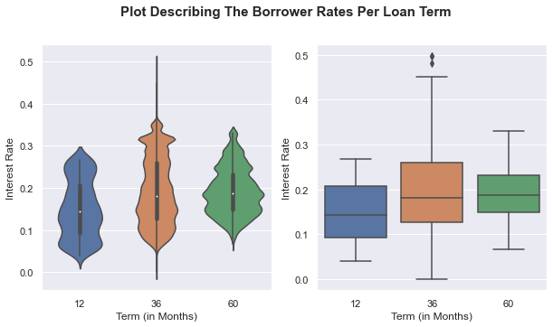

```python
factor_plot('Term', 'BorrowerRate', data=loan_data, xlabel='Term (in Months)', ylabel='Interest Rate', height=10, width=5,
           title='Plot Describing The Borrower Rates Per Loan Term', rotation=0)
```

**36 Month loans have some outliers and a fairly higher median than the 12 month offers**

```
> BorrowerRate & IncomeRange
```

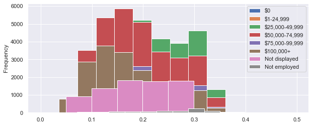

```python
# setting parameters for visualization
sns.set(rc={'figure.figsize':(10,4)})

# plotting visual
loan_data.groupby('IncomeRange')['BorrowerRate'].plot.hist();
plt.legend();
```

**The common/median salary range happen to appear on the rightmost parts where the highest rates are with the low earners of the median range having the most people. The higher percentage of those with the lower rates are often found with high income earners.**

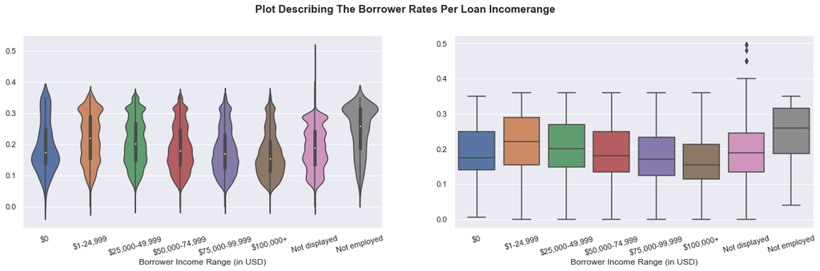

```python
factor_plot('IncomeRange', 'BorrowerRate', data=loan_data, xlabel='Borrower Income Range (in USD)', height=20, width=5,
           title='Plot Describing The Borrower Rates Per Loan IncomeRange', rotation=15)
```

**These violion and boxplots Further unveils more insight as to the median rates per IncomeRange**

```
> BorrowerRate per LoanStatus
```

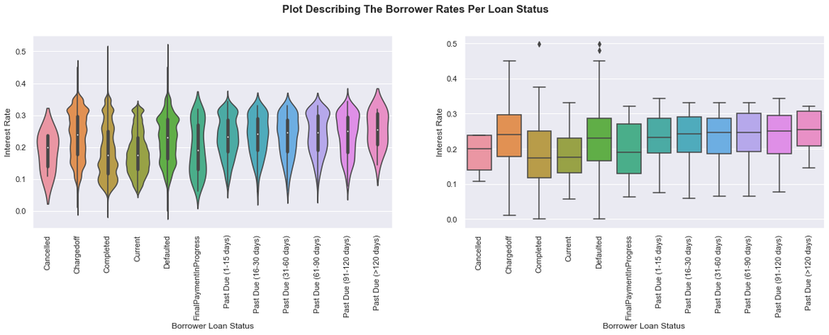

```python
factor_plot('LoanStatus', 'BorrowerRate', data=loan_data, xlabel='Borrower Loan Status', ylabel='Interest Rate',
                title='Plot Describing The Borrower Rates Per Loan Status', rotation=90, height=20, width=5)
```

```
> BorrowerRate & EmploymentStatus
```